# Effects of Loan Characteristics on Loan Status

## by Ndidi Charles Nweke

## Investigation Overview

The objective here is to understand "What factors affect a borrower’s ability to pay back a loan?" -- Loan Status. The focus was on exploring several features that could affect the Loan Status like Loan term, Stated Monthly Income, monthly loan payment, Income range and employment status to see how they contribute to borrower's ability to pay back a loan.

I looked at the distribution of loan status, the Employment status. Then the correlation of the Stated monthly Income, Monthly repayment and the loan term. I went further to create the loan-income-ratio column which combines monthly income and monthly loan payment.

## Dataset Overview

The dataset consists of 113937 rows and 81 columns of loan data. It is financial dataset related to loan, borrowers, investors, interest rates and more. 22 features were collected and used for the analysis.

## Distribution of Loan Status

Let us explore the main variable of interest which is the Loan Status (Cancelled, Chargedoff, Completed, Current, Defaulted, FinalPaymentInProgress, PastDue.). All the past due dates were merged into one.

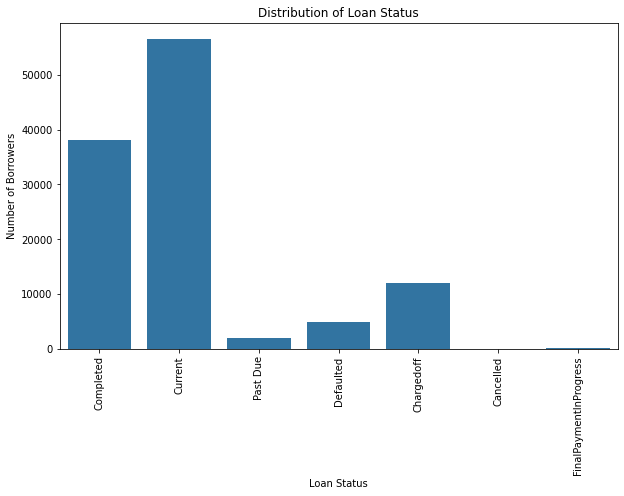

## Distribution of Employment Status

Being employed, whether working for someone or self-employed proves someone's ability to pay back a loan. Despite different categories given to the Employment status column, a large amount of the borrowers partake in one work or the other.

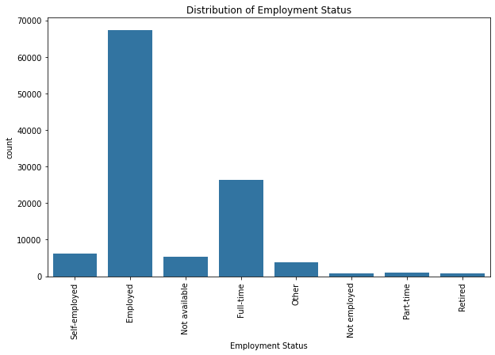

## Correlation of Interested Numeric Variables

Did a correlation of StatedMonthlyIncome, MonthlyLoanPayment, Term to understand their significance for the analysis. At first, I believe these variables will help us get an answer, but let's confirm further.

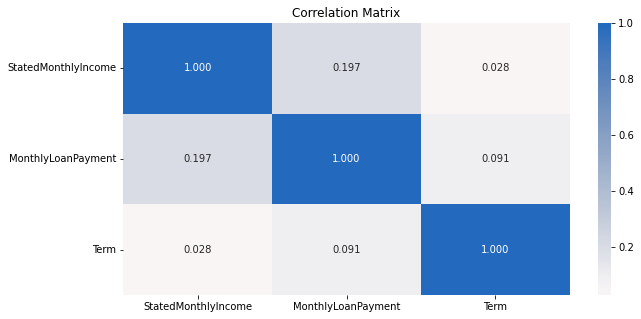

## Loan-Income-Ratio vs Loan term against Loan Status

The correlation of the three variables implies that there is hope. However, since to be able to pay back a loan one needs to be working and also, their monthly income should be enough to take them through the month alongside paying their loan. Let's create a column Loan-Income-Ratio **(MonthlyLoanPayment/StatedMonthlyIncome)*100)** which would be a measure of how much borrowers are setting aside for loan repayments.

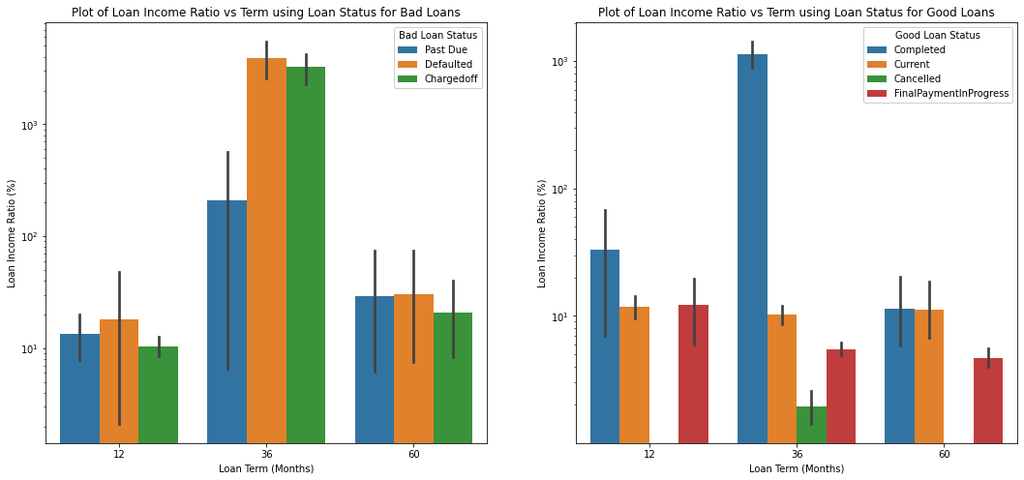

## Loan Income Ratio vs Employment Status and Loan Status

From the below, loan-income-ratio for the bad loans segment showed a high variance along the part-time workers, employed, other, and retired. This is a sign of borrowing above one's monthly income. Although the same variance is obtainable for the retired in the good loans part, we believe they have other income sources that cannot immediately accounted for.

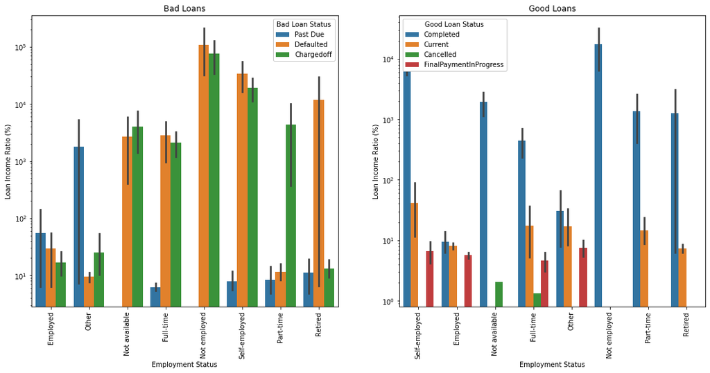